# Time Series

Luis Biedma

13 diciembre, 2021

```r
library(tidyverse)
library(tsbox)
library(ggfortify)
library(lubridate)
library(forecast)
library(tsibble)
library(feasts)
```

## Time series objects

Base R has a time-series object class `ts`. We can pass a vector specify the starting date and the periodicity and we get a `ts` object.

```r
qb <- eurostat::get_eurostat("namq_10_gdp", filter = list(
  geo = "EU27_2020",
  na_item = "B1GQ",
  s_adj = "SCA",
  unit = "CLV15_MEUR"
)) %>%
  na.omit() %>%
  select(values) %>%
  ts(frequency = 4, start = c(1995, 1))

head(qb)
```

```
##         Qtr1    Qtr2    Qtr3    Qtr4
## 1995 2188996 2212667 2221381 2233497
## 1996 2233443 2249558
```

This brings a lot of advantages. We can directly plot the object

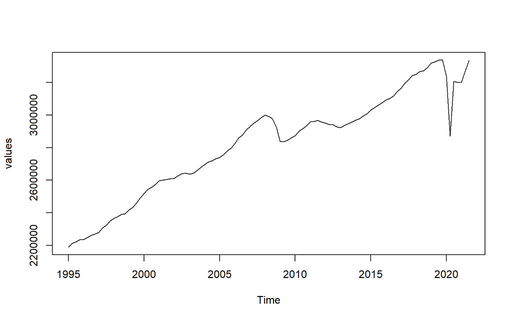

```r
plot(qb)
```

Or convert it

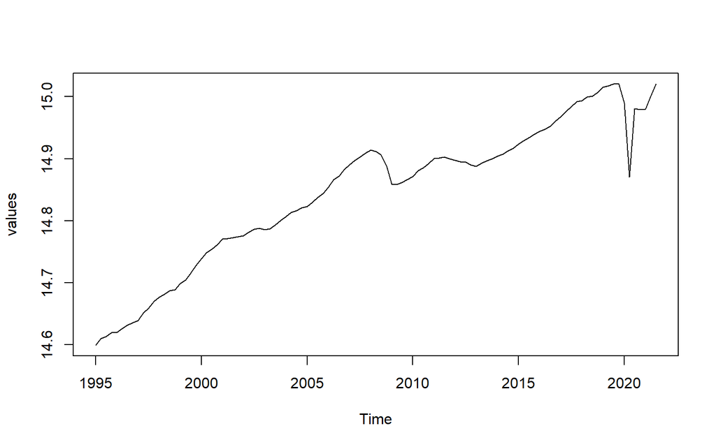

```r
logqb <-log (qb)
plot(logqb)
```

Decompose it.

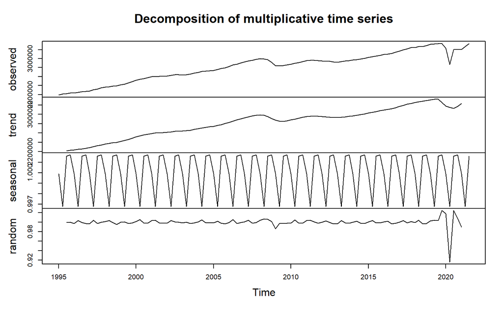

```r
comp<- decompose(qb, type = c("multiplicative"))
plot(comp)
```

We can see already the seasonal component of the series.

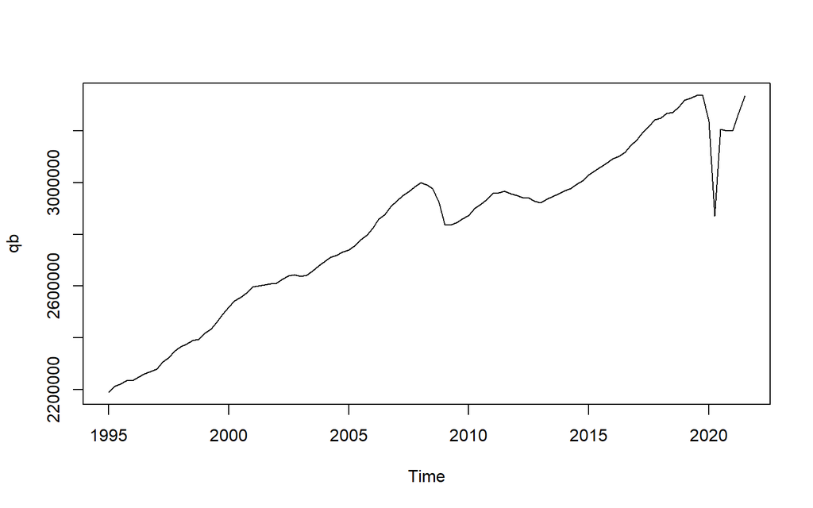

```r
seas_qb <- qb- comp$seasonal
plot(seas_qb)
```

We can fit an arima model.

```r
arima(qb)
```

```
##
## Call:
## arima(x = qb)
##
## Coefficients:
##        intercept
##       2820940.34
## s.e.    30320.98
##
## sigma^2 estimated as 9.839e+10:  log likelihood = -1506.03,  aic = 3016.06
```

and more sophisticated things, for example using the package **{forecast}**, we can get a forecast with confidence intervals.

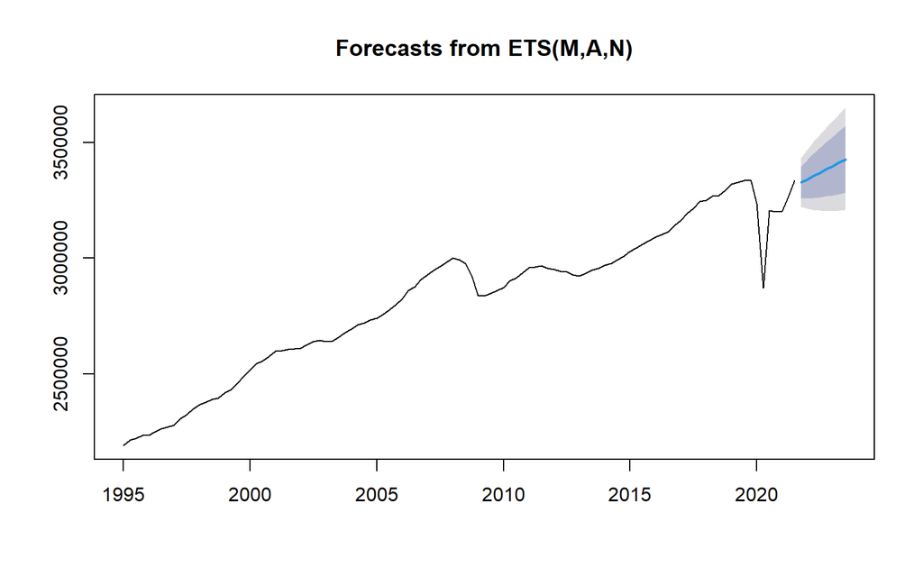

```r
f_qb <-forecast::forecast(qb)

plot(f_qb)
```

We see that the forecast produces an object that is a list.

```r
str(f_qb)
```

```
## List of 10
##  $ model    :List of 19
##   ..$ loglik    : num -1396
##   ..$ aic       : num 2802
##   ..$ bic       : num 2815
##   ..$ aicc      : num 2802
##   ..$ mse       : num 2.58e+09
##   ..$ amse      : num 3.95e+09
##   ..$ fit       :List of 4
##   .. ..$ value  : num 2792
##   .. ..$ par    : num [1:4] 6.78e-01 1.03e-04 2.18e+06 1.44e+04
##   .. ..$ fail   : int 0
##   .. ..$ fncount: int 261
##   ..$ residuals : Time-Series [1:107] from 1995 to 2022: -0.00409 0.00288 -0.00164 -0.00155 -0.00693 ...
##   ..$ fitted    : Time-Series [1:107, 1] from 1995 to 2022: 2197991 2206309 2225036 2236974 2249033 ...
##   .. ..- attr(*, "dimnames")=List of 2
##   .. .. ..$ : NULL
##   .. .. ..$ : chr "y"
##   ..$ states    : Time-Series [1:108, 1:2] from 1995 to 2022: 2183574 2191893 2210619 2222558 2234617 ...
##   .. ..- attr(*, "dimnames")=List of 2
##   .. .. ..$ : NULL
##   .. .. ..$ : chr [1:2] "l" "b"
##   ..$ par       : Named num [1:4] 6.78e-01 1.03e-04 2.18e+06 1.44e+04
##   .. ..- attr(*, "names")= chr [1:4] "alpha" "beta" "l" "b"
##   ..$ m         : num 4
##   ..$ method    : chr "ETS(M,A,N)"
##   ..$ series    : chr "object"
##   ..$ components: chr [1:4] "M" "A" "N" "FALSE"
##   ..$ call      : language ets(y = object, lambda = lambda, biasadj = biasadj, allow.multiplicative.trend = allow.multiplicative.trend)
##   ..$ initstate : Named num [1:2] 2183574 14417
##   .. ..- attr(*, "names")= chr [1:2] "l" "b"
##   ..$ sigma2    : num 0.000264
##   ..$ x         : Time-Series [1:107, 1] from 1995 to 2022: 2188996 2212667 2221381 2233497 2233443 ...
##   .. ..- attr(*, "dimnames")=List of 2
##   .. .. ..$ : NULL
##   .. .. ..$ : chr "values"
##   ..- attr(*, "class")= chr "ets"
##  $ mean     : Time-Series [1:8] from 2022 to 2024: 3327836 3342191 3356546 3370901 3385256 ...
##  $ level    : num [1:2] 80 95
##  $ x        : Time-Series [1:107, 1] from 1995 to 2022: 2188996 2212667 2221381 2233497 2233443 ...
##   ..- attr(*, "dimnames")=List of 2
##   .. ..$ : NULL
##   .. ..$ : chr "values"
##  $ upper    : Time-Series [1:8, 1:2] from 2022 to 2024: 3397105 3426133 3453057 3478617 3503203 ...
##   ..- attr(*, "dimnames")=List of 2
##   .. ..$ : NULL
##   .. ..$ : chr [1:2] "80%" "95%"
##  $ lower    : Time-Series [1:8, 1:2] from 2022 to 2024: 3258567 3258250 3260035 3263185 3267308 ...
##   ..- attr(*, "dimnames")=List of 2
##   .. ..$ : NULL
##   .. ..$ : chr [1:2] "80%" "95%"
##  $ fitted   : Time-Series [1:107, 1] from 1995 to 2022: 2197991 2206309 2225036 2236974 2249033 ...
##   ..- attr(*, "dimnames")=List of 2
##   .. ..$ : NULL
##   .. ..$ : chr "y"
##  $ method   : chr "ETS(M,A,N)"
##  $ series   : chr "qb"
##  $ residuals: Time-Series [1:107] from 1995 to 2022: -0.00409 0.00288 -0.00164 -0.00155 -0.00693 ...
##  - attr(*, "class")= chr "forecast"
```

We can access its elements inside the list, for example, the mean forecast and the upper and lower values.

```r
f_qb$mean
```

```
##         Qtr1    Qtr2    Qtr3    Qtr4
## 2021                         3327836
## 2022 3342191 3356546 3370901 3385256
## 2023 3399611 3413965 3428320
```

```r
f_qb$lower
```

```
##             80%     95%
## 2021 Q4 3258567 3221899
## 2022 Q1 3258250 3213814
## 2022 Q2 3260035 3208946
## 2022 Q3 3263185 3206163
## 2022 Q4 3267308 3204871
## 2023 Q1 3272171 3204708
## 2023 Q2 3277618 3205440
## 2023 Q3 3283540 3206899
```

```r
f_qb$upper
```

```
##             80%     95%
## 2021 Q4 3397105 3433774
## 2022 Q1 3426133 3470569
## 2022 Q2 3453057 3504147
## 2022 Q3 3478617 3535639
## 2022 Q4 3503203 3565641
## 2023 Q1 3527050 3594513
## 2023 Q2 3550313 3622491
## 2023 Q3 3573100 3649742
```

Most R packages for time series work with `ts` objects. The cost is that for working with several time series we will need to work with lists. Also it is more difficult to filter, subset, etc. For example to filter values after 2019Q1.

```r
window(qb, start=c(2019,1))
```

```
##         Qtr1    Qtr2    Qtr3    Qtr4
## 2019 3319298 3327512 3336987 3338599
## 2020 3236443 2870811 3206214 3200930
## 2021 3200845 3267820 3336340
```

There are some relatively new libraries **{tsbox}** for conversion and other operations and **{tsibble}** and **{feasts}** allowing tidyverse verbs that make manipulating multiple time series much easier.

## Tsbox

With **{tsbox}** we can easily convert back and forth between several object classes (ts, dataframes, data tables, tsibble…).

```r
qb_ts <-qb
qb_df <- ts_df(qb_ts)
qb_df
```

```
##           time   value
## 1   1995-01-01 2188996
## 2   1995-04-01 2212667
## 3   1995-07-01 2221381
## 4   1995-10-01 2233497
## 5   1996-01-01 2233443
## 6   1996-04-01 2249558
## 7   1996-07-01 2261362
## 8   1996-10-01 2269421
## 9   1997-01-01 2278602
## 10  1997-04-01 2306509
## 11  1997-07-01 2322889
## 12  1997-10-01 2348909
## 13  1998-01-01 2365486
## 14  1998-04-01 2375809
```

[output cut: 93 more lines]

```r
qb_dt <-ts_dt(qb_ts)
qb_dt
```

```
##            time   value
##   1: 1995-01-01 2188996
##   2: 1995-04-01 2212667
##   3: 1995-07-01 2221381
##   4: 1995-10-01 2233497
##   5: 1996-01-01 2233443
##  ---
## 103: 2020-07-01 3206214
## 104: 2020-10-01 3200930
## 105: 2021-01-01 3200845
## 106: 2021-04-01 3267820
## 107: 2021-07-01 3336340
```

```r
qb_tsibble <- ts_tsibble(qb_ts)
qb_tsibble
```

```
## # A tsibble: 107 x 2 [1D]
##    time          value
##    <date>        <dbl>
##  1 1995-01-01 2188996.
##  2 1995-04-01 2212667.
##  3 1995-07-01 2221381.
##  4 1995-10-01 2233497.
##  5 1996-01-01 2233443.
##  6 1996-04-01 2249558
##  7 1996-07-01 2261362.
##  8 1996-10-01 2269421.
##  9 1997-01-01 2278602.
## 10 1997-04-01 2306509.
## # ... with 97 more rows
```

That allows us to calculate the functions of tsbox on any class of object.

Normalise series to zero

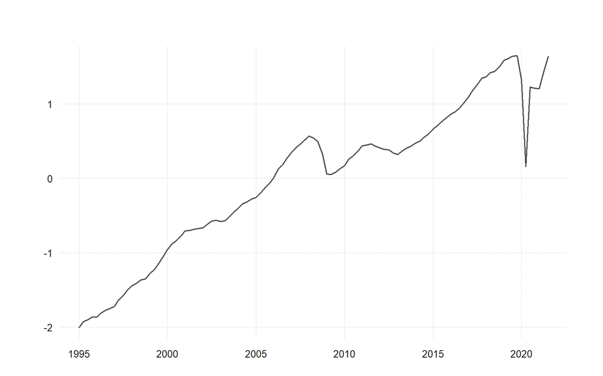

```r
ts_plot(ts_scale(qb_ts, center = TRUE))
```

plot the trend

```r
ts_dygraphs(ts_trend(qb_df))
```

[interactive chart not shown]

Several growth rates

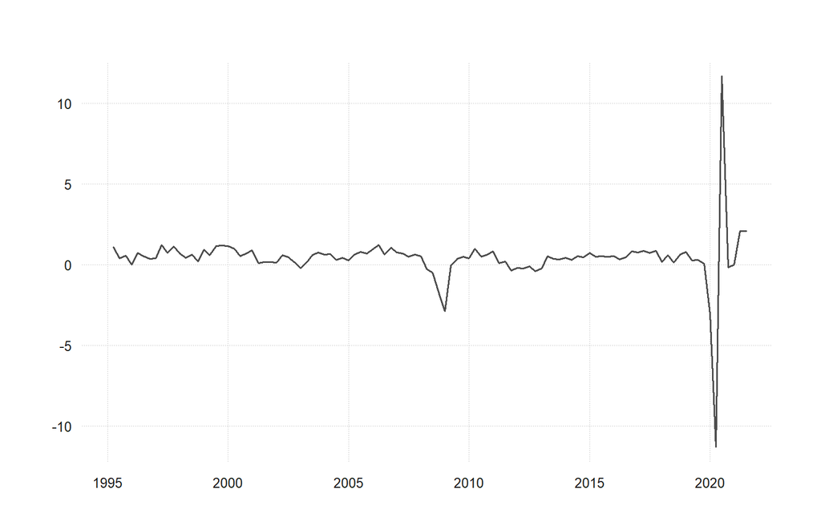

```r
ts_plot(ts_pc(qb_dt)) # calculate quarterly growth rates
```

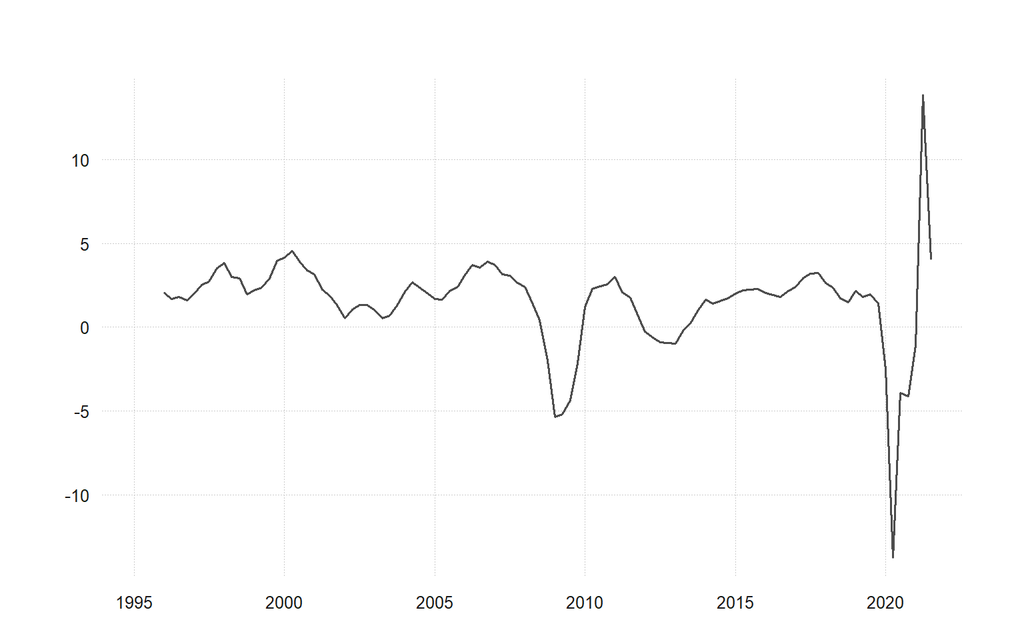

```r
ts_plot(ts_pcy(qb_dt)) # calculate year on year growth rates
```

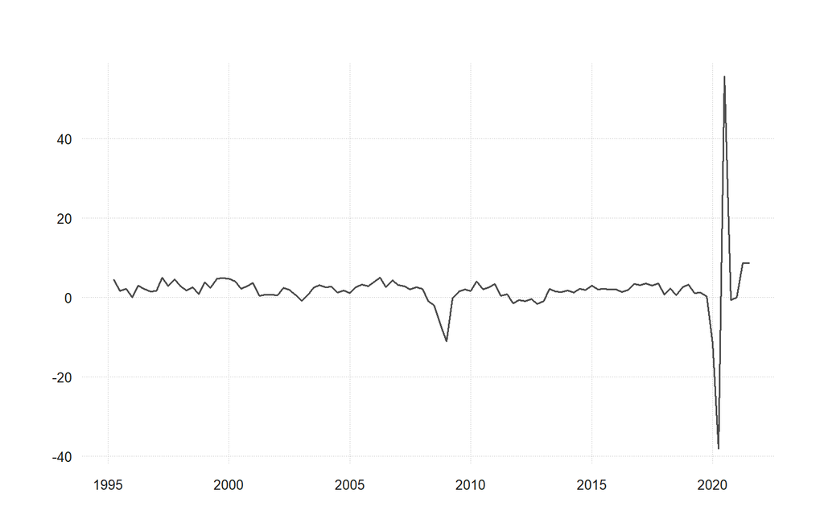

```r
ts_plot(ts_pca(qb_dt)) # calculate annualised growth rates
```

```r
ts_frequency(qb_tsibble, to ="year", aggregate="mean")# coonvert to annual average
```

```
## # A tsibble: 26 x 2 [1D]
##    time          value
##    <date>        <dbl>
##  1 1995-01-01 2214135.
##  2 1996-01-01 2253446.
##  3 1997-01-01 2314227.
##  4 1998-01-01 2381673.
##  5 1999-01-01 2449750.
##  6 2000-01-01 2547947.
##  7 2001-01-01 2602761
##  8 2002-01-01 2630365.
##  9 2003-01-01 2653750.
## 10 2004-01-01 2714717.
## # ... with 16 more rows
```

## Feasts

We load a dataframe with several variables and convert it to a tsibble. It is important to let tsibble now that the periodicity is quarter otherwise he might understand there are gaps in the data.

```r
df_full <- eurostat::get_eurostat("namq_10_gdp", time_format = "date", filter = list(
  geo = "EU27_2020",
  na_item = "B1GQ",
  s_adj = "NSA",
  unit = c("CLV15_MEUR", "CP_MEUR")
)) %>%
  select(time,geo, na_item, unit,values) %>%
  mutate(time = lubridate::ymd(time)) %>%
  na.omit()

df_full<- ts_tsibble(df_full) %>%
mutate(time=yearquarter(time))# do not forget this
```

We can create easily a so-called seasonal graph.

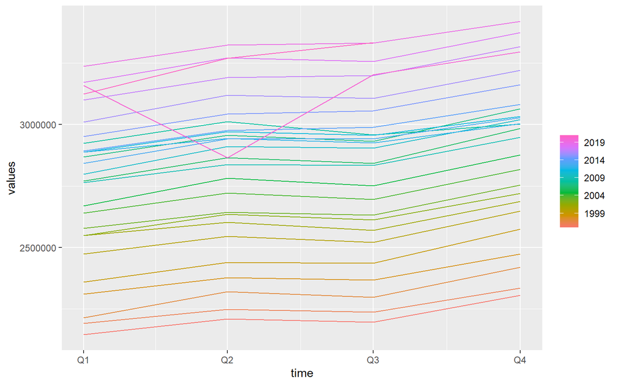

```r
df_full %>%
  filter(unit=="CLV15_MEUR" ) %>%
  gg_season()
```

Compare the seasonality of a transaction in different prices.

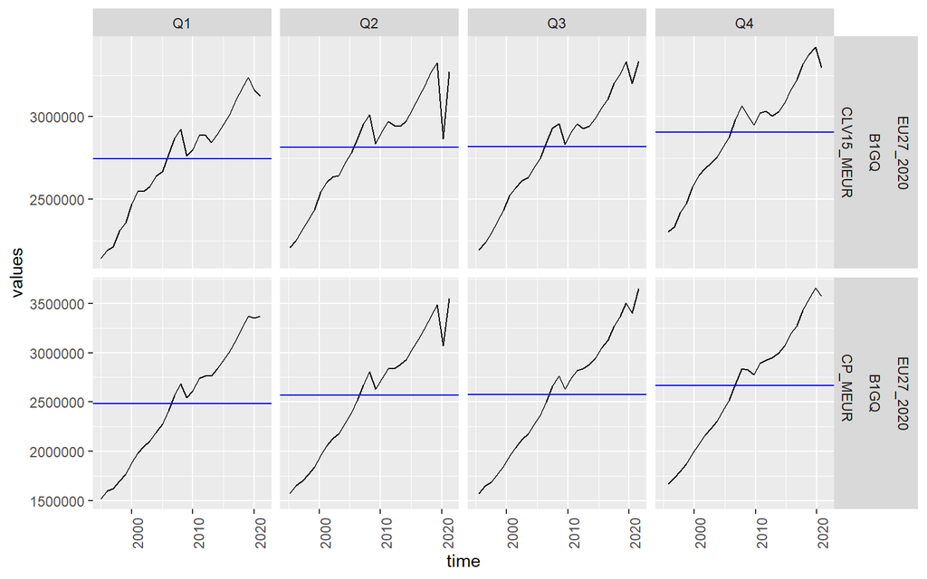

```r
df_full %>%
  group_by(unit) %>%
  gg_subseries()
```

or check in a nice graph the classical decomposition.

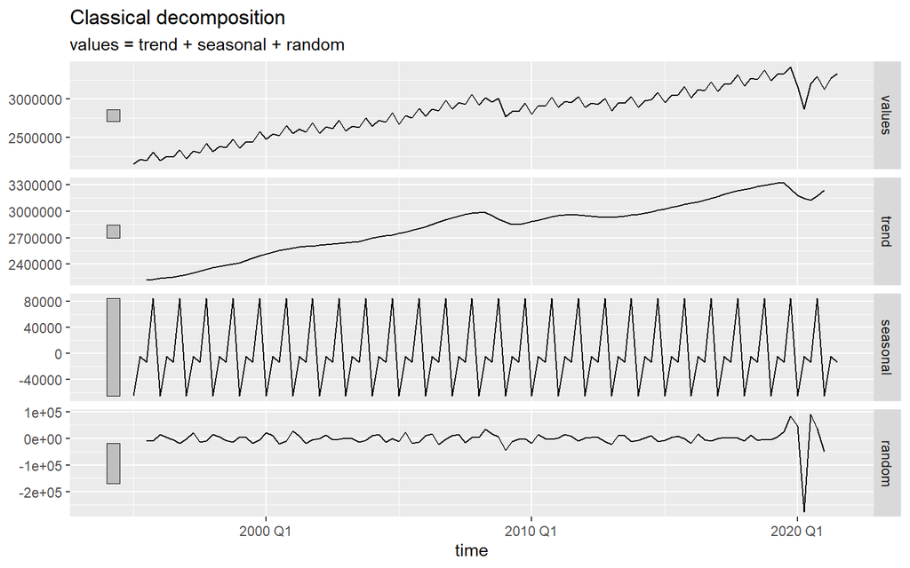

```r
comp<- df_full %>%
filter(unit =="CLV15_MEUR") %>%
  select(time, values) %>%
  model(stl=classical_decomposition(values))

components(comp) %>%
  autoplot()
```

or a SEATS decomposition. but we will need the {seasonal} package which cannot be installed in the Commission laptops.

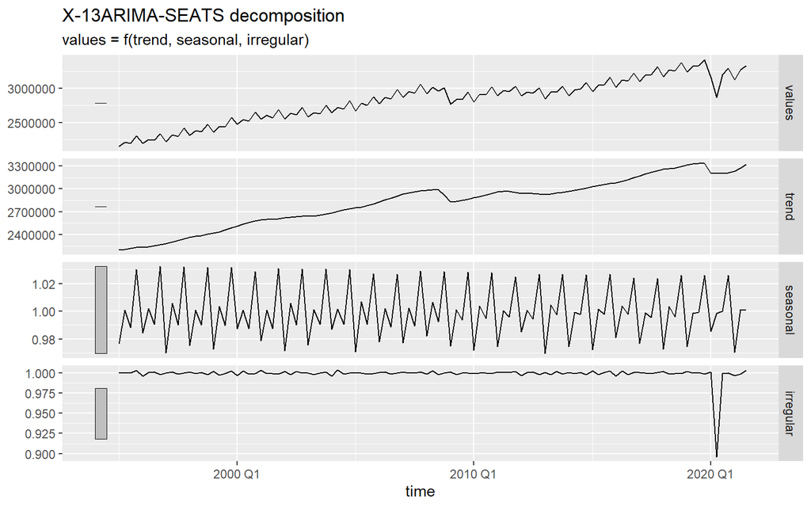

```r
comp<- df_full %>%
filter(unit =="CLV15_MEUR") %>%
  select(time, values) %>%
  model(seats = X_13ARIMA_SEATS(values ~ seats()))

components(comp) %>%
  autoplot()
```